https://www.renarepenning.com/weplaynoladata/

# Rena Repenning and Eddy Salazar

###### Intro to Data Science Service Learning - CMPS3160-01 <sup>0</sup>

Dr Nicholas Mattei, Tulane University

Fall 2021

[figure not shown]

We PLAY logo<sup>1,</sup><sup>3</sup>

# Project Plan

### Data

We PLAY Data <sup>2</sup> Provided by Christine Neely from Training Grounds NOLA. Available on this project's [Git repository](https://github.com/renarepenning/weplaynoladata/tree/main/_data).

### Explanation & Model Proposition

We are inspired by The We PLAY center's mission "to assist parents, caregivers, and professionals with providing children birth to five years of age with rich learning experiences, positive adult-child interactions, and social-emotional skills that will contribute to success in school and beyond." Melanie Richardson and Christine Neely proposed *Survey Data Synthesis* to Intro to Data Science’s service-learning students

The presented data contained five google sheets, a project description, and a Logic Model. Four of the five sheets were pulled from Incoming Parent Reflection Forms (an almost identical survey), and one is a Family Survey with similar but not identical questions. Although extensive, the data proved very difficult to wrangle because of its messy form. We aim to provide recommendations to facilitate future data analysis with less ETL.

Along with survey data<sup>4</sup>, Christine Neely provided us with a Logic Model submitted to their IMH Grant proposal. The organization's goal is stated as "*Strengthening social-emotional interaction among children ages birth-3 yrs and parents at the We PLAY Center will lead to stronger communities, thriving families and children who are ready to learn.*" This document's Output Targets and Indicators of Success were guidance for the following data analysis. We PLAY assumes that "embedding [...] the center in low-income communities will yield participation" in utilizing and applying parenting information to families desire. To combat the disorganization of the income data we created a new sheet with appropriate labeling and all five datasets.

### Our Focus

We intend to model WE Play's current demographics, strengths, and provide recommendations for future data collection. To do so we will:

- Use data regarding existing and desired parenting skills to inform We PLAY's curriculum
- Identify why people chose We PLAY over alternative forms of childcare/early education
- Examine how parents feel they have grown since attending We PLAY
- Visualize parents requests for an increase in certain types of education at We PLAY

### Recommendations

There are a few improvements we believe could be made to the survey process to ensure a higher volume of quality data is collected. The surveys we used were from irregular time intervals which affect the quality of the data that is recorded. Sending out surveys in more intervals, like quarterly would be an improvement. Some survey questions were essentially the same, so going through and removing questions that are too similar would improve the experience of someone taking the survey. We recommend surveys track a participent's attendance frequency and time spend in the program. Finally, We PLAY would benefit from employing one survey format. This would allow easier comparison between all data and provide more useful insights.

### Recommendations - Bulleted

- Create a long term survey plan
- Chose uniform time interval, ie quarterly
- Create questions to directly gauge progress
- Track more quantitative data about respondents: Measure tax bracket, the ratio of children to adults in the family
- Gather attendance frequency and longevity data

Tailor questions to IMH logic model

- Survey tests parents’ POV, not progress
- Create questions to directly gauge progress

### Process

Data transformation was the most time-intensive step of the data life cycle. First, we manually removed empty columns and rows from the five excel files. Then, we broke apart sheets to make data frames addressing a single concern. During service learning, Melanie and Christine heard our Milestone Two plan and requested further investigation into participants’ income levels relating to their requested information and zip code.

Graphing pie charts is difficult, and code-intensive, in pandas and matplotlib. Writing three of our own ETL functions increased our efficiency and cut down on lines of code. We added functions to plot pie charts easily, grab column labels, and take numerical series and plot a bar chart, and print summary stats. These will allow us to analyze the rest of the data in a much more efficient fashion.

### Collaboration Plan

Rena and Eddy will utilize this repository to simultaneously edit the project. We plan on connecting over Zoom as needed and keeping constant communication over instant messages. Also, we are both able to meet after class on Thursdays. When convenient, we will export notebooks to Google Colabs to support simultaneous editing. (This is easily done using a Colabs Chrome extension). While re-organizing our final product we used a GoogleDoc to simultaneously outline and plan.

### Footnotes

0. https://nmattei.github.io/cmps3160/

1. Image source: https://www.mytraininggrounds.org/we-play-center.

2. We PLAY data was last downloaded on October 25th, 2021.

3. Cite: https://stackoverflow.com/questions/14675913/changing-image-size-in-markdown)

4. Access the data and Logic Model [here](https://github.com/renarepenning/weplaynoladata/tree/main/_data)

5. Cites:

- https://matplotlib.org/stable/tutorials/colors/colormaps.html
- https://matplotlib.org/3.1.0/api/_as_gen/matplotlib.pyplot.pie.html
- https://matplotlib.org/stable/gallery/pie_and_polar_charts/pie_features.html </span>

6. 2020 US Census Bureau data: https://www.census.gov/quickfacts/fact/table/neworleanscitylouisiana/INC110219

###### Check out our final presentation slides [here](https://github.com/renarepenning/weplaynoladata/blob/main/PresentationSlides.pdf)

# Exploring We PLAY Survey Results

##### Imports as needed

```python
import pandas as pd
import matplotlib.pyplot as plt
import numpy as np
import math
import random
!pip3 install openpyxl # package to open xlsx files
```

##### Separate paths to accomodate for our local environments

```python
renapath = "../notebooks/_data/WePlayData/CleanedWPC"
edpath = "./_data/WePlayData/CleanedWPC"
path = renapath  # path to manually cleaned excels
```

## Extraction, Transform, and Loading Key Functions

Matplotlib pie charting functions are cumbersome and do not offer flexability while labeling. During Milestone 1 we found ourselves spending more time on graphing than working with data. Writing graphing functions, custom to this project spend up ETL and improved output quality. </br>Below is our code documentation:

#### plotPies() <sup>5</sup>

- df -- dataframe to graph
- cols -- the df's columns to be used as titles; can pass in `getLabels(df)`
- labels -- labels for sections
- allLabelsSame -- if True, make a list of labels' to get same format for all label inputs
- isNAct -- if we use .isna() before value counts
- ishoriz=True -- Option to display pies horizontally.</br> *NOTE: Matplotlib would not support 2D plotting with varying sizes. Oftentimes we broke sections in half to avoid plotting too many on one axis.*
- showKeys=True
- fig1size=(20,5) -- able to change figure size to condense graphs For now, we will leave legends repeating because that function pairs names and values correctly.

#### getLabels()

Returns a list of lists of values for each column, using pandas.unique. Will print Nans! Unfortunately, labeling is inconsistent when filterning them out.

#### getColor()

Returns a random selection of one of We PLAY's colors. Used to alternate colors for `printCarBars()` and `printHorizBars()`.

#### printCatBars()

- df
- key
- att  
  Essentially `df.key`, Pandas doesn't allow .key in place of .attributename whe calculating summary stats
- printStats=True -- Option to skip printing stats for categorical variables

#### printHorizBars()

Inended for categorical variables with "long" labels.

- df
- key

#### plotSection()

Streamlines plotting columns of the aggregated `allIncoming` df. Takes in indexes and calls other functions appropriately. Cannot be used on other data frames.

- cols
- i1
- i2
- plotBars="key"
- plotBarsHoriz=False
- pie=True

```python
def plotPies(df, labels, allLabelsSame, isNAct, ishoriz=True, showKeys=True, fig1size=(20,5)):
    theme=['#794f9e','#55ad51','#db6ea1','#a8a8a8','#b297c9','#8fbf8e','#d6aec0','#6e6e6e','#4a395e'] #We PLAY colors
    cols = df.columns
    # create matplotlib axis, can be done vertically. Unfortunately figsize required int literals.
    if ishoriz:
        fig1, ax1 = plt.subplots(nrows=1,ncols=len(cols),figsize=fig1size)
    else:
        fig1, ax1 = plt.subplots(nrows=len(cols),ncols=1,figsize=fig1size)
    if allLabelsSame:
        # turns single list into same format outputted by `getLabels()`
        labels = [labels]*len(cols)
    #print key above all instead of individually
    keys = []
    for i, c in enumerate(df.columns): # incase our graph titles are going to be differend
        if isNAct:
            # To plot using is na
            wedges, = ax1[i].pie(df[c].isna().value_counts(), colors=theme, autopct='%1i%%',textprops={'fontsize': 12, 'color':'w','weight':'bold'}, shadow=True, startangle=90),
        else:
            wedges = ax1[i].pie(df[c].value_counts(), colors=theme, autopct='%1i%%',textprops={'fontsize': 12, 'color':'w','weight':'bold'}, shadow=True, startangle=90)
        ax1[i].set_title(str(i+1))
        if isinstance(cols[i],str):
            keys += [str(i+1) +". "+ cols[i]]
        else:
            keys += [str(i+1) +". "+ cols[i][0]]
        ax1[i].axis('equal')
        # label individually, when we must
        if allLabelsSame == False:
            ax1[i].legend(wedges[0], labels[i],
                  title="Legend", # must plot a unique legend for each to keep value/label pairs uniform
                  loc="upper left",
                  bbox_to_anchor=(1, 0, 0.5, 1))
    # label for all to save space
    if allLabelsSame:
        ax1[0].legend(wedges[0], labels[0],
                      title="Legend", # must plot a unique legend for each to keep value/label pairs uniform
                      loc="upper left",
                      bbox_to_anchor=(1, 0, 0.5, 1))
    # Label each graph - matplot title is messy
    if showKeys == True: # Option to omit keys
        print("KEYS:")
        for k in keys:
            print(k)
        plt.show()
```

```python
def getLabels(df):
    # beware: will return nan
    labels = ["x"]*len(df.columns)
    for i, c in enumerate(df.columns):
        labels[i] = df[c].unique()
    return labels
```

##### Displaying catagorical barcharts with option of summary stats for numeric variables

```python
def getColor():
    theme=['#794f9e','#55ad51','#db6ea1']
    random.seed()
    i = random.randrange(3)
    return theme[i]
```

```python
def printCatBars(df, key, att, printStats=True): # att -- > is df.col_name attribute for calling summary stat functions
    p = df[key].value_counts()
    p.sort_index(inplace=True)
    p.plot.bar(align="center", color=getColor())
    if printStats: # skip for qualitative data
        # convert numeric values
        df[key].apply(pd.to_numeric, errors='coerce')
        print("SUMMARY STATS\n","AVG: ", att.mean()[0],"\nMax,Min: ",att.min()[0],",",att.max()[0])

# printing horizontal bar charts for qualitative values with long labels
def printHorizBars(df, key):
    p = df[key].value_counts()
    p.sort_index(inplace=True)
    p.plot.barh(align="center", color=getColor())
```

##### Plotting batches of aggregated data, with option to add in/change to bar chart

```python
def plotSection(cols, i1, i2, plotBarsHoriz=False, plotBars="key", pie=True, isNAct=False):
    df = allIncoming.iloc[1:, i1:i2]
    df.columns = [cols]
    if (pie) and (plotBarsHoriz==False):
        # use labels function if non-bin question. else we make it T/f
        if isNAct == False:
            plotPies(df, getLabels(df), False, isNAct, True)
        else:
            plotPies(df, ["True", "False"], True, isNAct, True)
    if plotBars != "key":
        if plotBarsHoriz == False:
            print("Taking a closer look at ",plotBars,":")
            printCatBars(df, plotBars, df[plotBars], False)
        else:
            printHorizBars(df, plotBars)
```

# Surveys

We recieved two survey formats: `Incoming Parent Reflection` and `Family Survey`

### Incoming Family Data

Aggregation of four "Incoming Parent Reflection Suverys." Dated from July 2019, November 2019, 2020, and an undated version from 2019. These sheets appear to be from the same survey, but the undated sheet seemed to differ slightly in column order. This was able to be fixed manually or by dropping indexes.

```python
# JULY BATCH
incomingjuly2019 = pd.read_excel(path + "IncomingParentReflection-July2019" + ".xlsx")
incomingjuly2019["Sheet"] = "July19"
incomingjuly2019.drop([1], axis=0, inplace = True) #delete row full of test reponses
# NOV BATCH
incomingnov2019 = pd.read_excel(path + "IncomingParentReflection-November2019" + ".xlsx")
incomingnov2019["Sheet"] = "Nov19"
incomingnov2019.drop([0], axis=0, inplace = True)
# 2020 BATCH
incoming2020 = pd.read_excel(path + "IncomingParentReflectionForm2020" + ".xlsx")
incoming2020["Sheet"] = "2020"
incoming2020.drop([0], axis=0, inplace = True)
# UNDATED BATCH
incoming_undated = pd.read_excel(path + "IncomingParentReflection" + ".xlsx")
incoming_undated["Sheet"] = "NoDate"
# Create DF of all similar surveys
pd.set_option('display.max_columns',None) #display all columns
allIncoming = pd.concat([incomingjuly2019, incomingnov2019.iloc[1:,:], incoming2020.iloc[1:,:], incoming_undated.iloc[1:,:]], ignore_index=True)

print("Notes:  --\'Nan\' codes lack of reponse   -- Resp = Respondant\n        -- Adult implies 18 +           -- Child implies under 18 \n")
```

```
Notes:  --'Nan' codes lack of reponse   -- Resp = Respondant
        -- Adult implies 18 +           -- Child implies under 18
```

Distribution of data from each survey

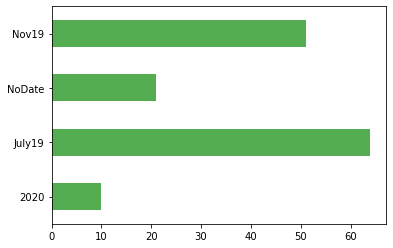

```python
printHorizBars(allIncoming,"Sheet")
```

### Family Survey Data

This section went through ETL seperately because of format and question differences. FamilySurvey.xlsx data was collected between Jan-Aug 2019. We suspect overvations overlap with those from Incoming Reflections.

```python
familySurveyDf = pd.read_excel(path + "FamilySurvey" + ".xlsx")
print("Above notes apply.")
adult_FDa = familySurveyDf.iloc[1:, :5]
adult_FDa.columns = [["Resp_Gender", "Resp_Age", "Resp_Race", "Children", "AdultsAtHome"]]
adult_FDb = familySurveyDf.iloc[1:, 5:10]
adult_FDb.columns = [["Zip", "OMIT", "Avg_Income", "highest_edu", "visits_Monthly"]]
adult_FDb.drop(columns=["OMIT"], inplace=True)#,level=level)
```

```
Above notes apply.
```

## Data

#### Reported demographics

Participant ID was coded by the survey, automatically and did not allow us to track Respondants between surveys.

###### Income

In the future, we recommend asking participents to report within a couple thousand dollars of their income.

###### Education

Survey respondants reported educational attainment levels consistent with New Orleans' broader demographic.

```
KEYS:
1. Income
2. Highest Level of education
```

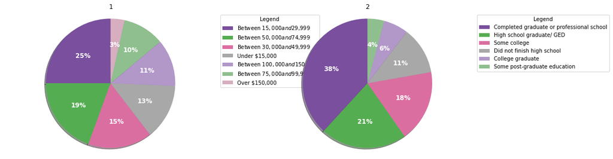

```python
plotSection(["Income", "Highest Level of education"], 9, 11)
```

```
INFORMATION REQUESTED BY SALARY -- KEYS
1. Stress relief
2. Information about community resources
3. Information about how to foster my child’s development
4. Information about nurturing and responsive parenting strategies
5. Information about mouthing (biting, putting objects in their mouth)
6. Information about conflict resolution
7. Information about sharing
8. Information about nursing/ feeding
9. Information about temper tantrums
10. Information about sleeping
Salary Range: Under $15,000
```

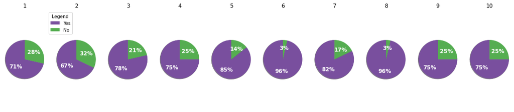

```python
incomeVsRequests = pd.read_excel(path + "Incomeandrequests" + ".xlsx")
under15k = incomeVsRequests[incomeVsRequests.AvgIncome == 'Under $15,000']
under30k = incomeVsRequests[incomeVsRequests.AvgIncome == 'Between $15,000 and $29,999']
under50k = incomeVsRequests[incomeVsRequests.AvgIncome == 'Between $30,000 and $49,999']
under75k = incomeVsRequests[incomeVsRequests.AvgIncome == 'Between $50,000 and $74,999']
under100k = incomeVsRequests[incomeVsRequests.AvgIncome == 'Between $75,000 and $99,999']
under150k = incomeVsRequests[incomeVsRequests.AvgIncome == 'Between $100,000 and $150,000']
over150k = incomeVsRequests[incomeVsRequests.AvgIncome == 'Over $150,000']
print("INFORMATION REQUESTED BY SALARY -- KEYS")
print('''1. Stress relief
2. Information about community resources
3. Information about how to foster my child’s development
4. Information about nurturing and responsive parenting strategies
5. Information about mouthing (biting, putting objects in their mouth)
6. Information about conflict resolution
7. Information about sharing
8. Information about nursing/ feeding
9. Information about temper tantrums
10. Information about sleeping''')
# charts are printed after all text, so we ran this in seperate cells to get accurate headers
def printincomerequests(d):
    print("Salary Range: " + d["AvgIncome"].unique()[0])
    d.drop(["AvgIncome"], axis=1, inplace = True)
    plotPies(d, ["Yes","No"], True, True, showKeys=False, fig1size=(20,4))
printincomerequests(under15k)
```

```
Salary Range: Between $15,000 and $29,999
```

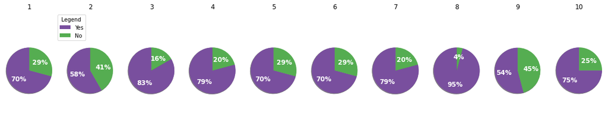

```python
printincomerequests(under30k)
```

```
Salary Range: Between $30,000 and $49,999
```

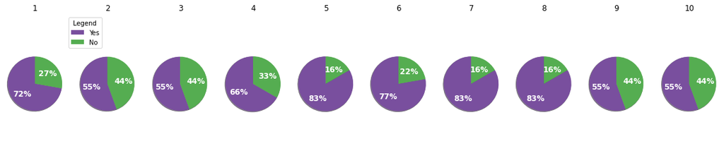

```python
printincomerequests(under50k)
```

```
Salary Range: Between $50,000 and $74,999
```

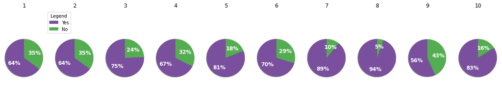

```python
printincomerequests(under75k)
```

```
Salary Range: Between $75,000 and $99,999
```

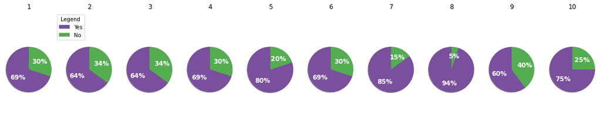

```python
printincomerequests(under100k)
```

```
Salary Range: Between $100,000 and $150,000
```

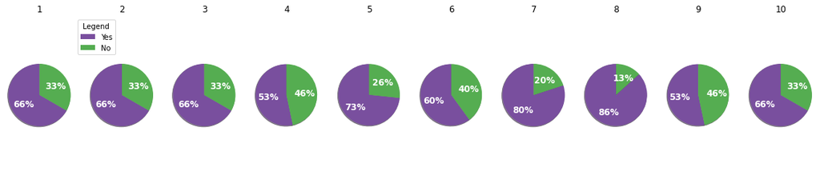

```python
printincomerequests(under150k)
```

```python
''' Only 3% of respondants fit into this category --> Ommitted due to quality '''
# printincomerequests(over150k)
```

```
' Only 3% of respondants fit into this category --> Ommitted due to quality '
```

## Demographics - Identity

#### General Survey Respondants

Responding caregivers are almost 90% female, and about 80% are within "child rearing" age between 25 and 45. Results suggest that mostly mothers, and a few grandparents bring children to the center. 73 % households report themselves as "single adult." This number may or may not exclude sibilings who are technically over 18.

```
KEYS:
1. Resp_Gender
2. Resp_Age
3. Resp_Race
```

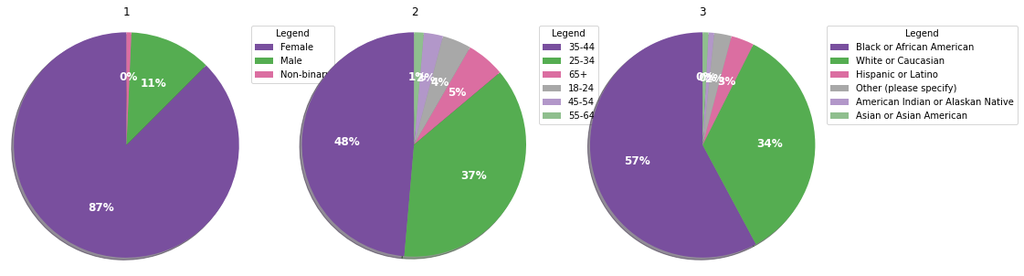

```
A closer look at racial demographics:
```

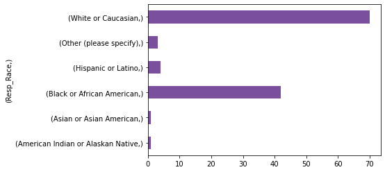

```python
plotSection(["Resp_Gender", "Resp_Age", "Resp_Race"], 1, 4)
print("A closer look at racial demographics:")
plotSection(["Resp_Race"], 3, 4, plotBarsHoriz=True, plotBars="Resp_Race")
```

### Family Survey Data

The Family Survey Reflects similar findings -- we suspect that many families overlapping in taking both surveys.

```
KEYS:
1. Resp_Gender
2. Resp_Race
3. Children
```

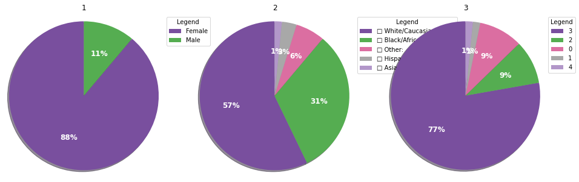

```python
# drop columns to plot bars
labels=getLabels(adult_FDa)
plotPies(adult_FDa, labels, False, False, True)
```

```
KEYS:
1. Avg_Income
2. highest_edu
3. visits_Monthly
```

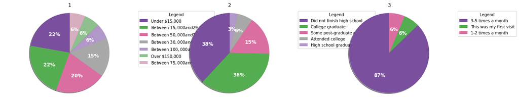

```python
labels=getLabels(adult_FDb)
plotPies(adult_FDb, labels, False, False, True)
```

##### Home population and Zipcode

We PLAY children grow up in overwhelingly single adult households. Estimates may be inflated because young adults are included as "Adults" but may not serve a gaurdian's role.

```
KEYS:
1. Adults
2. Children
```

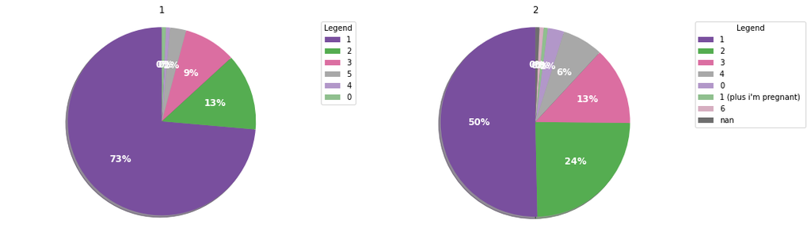

```python
plotSection(["Adults", "Children"], 5, 7)
```

### Zipcodes and attendance

Participants are traveling far, many from

- Fauborg St John (Median Income: ~40k)
- Bywater/Lower 9th ward (~$30k),
- Gentilly (~41k),
- Neighboring areas ie Uptown, Treme

Family survey results are similar to those from reflections.

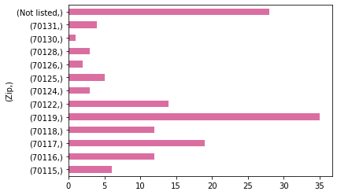

```python
# Incoming reflection aggregation
plotSection(["Zip"], 7, 8, plotBarsHoriz=True, plotBars="Zip")
```

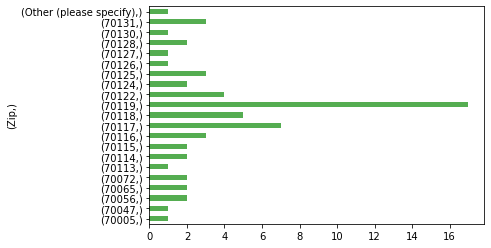

```python
# Family survey
printHorizBars(adult_FDb, "Zip")
```

Participants travel quite far to attend the We PLAY Center.

[figure not shown]

#### Attending children's demographic

- Only 28 out of 145 respdants provided this info on children
- Survey asked for gender and age of child 1 + age of child 2, age child three then relationship , relationship 2, other

We decided to omit ages and genders of third children because there was very little, sparse data.

```
KEYS:
1. 1st child age
2. 1st child's gender
3. resp relationship to 1st child
```

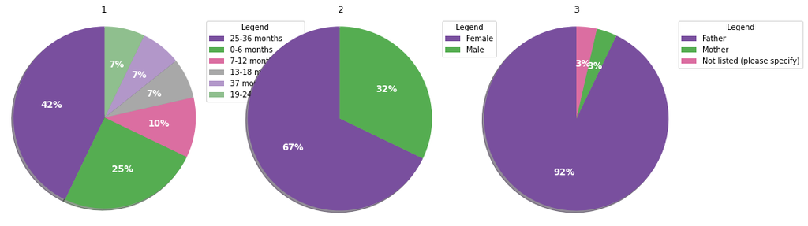

```
KEYS:
1. 2nd child age
2. 2nd child's gender
3. resp relationship to 2nd child
```

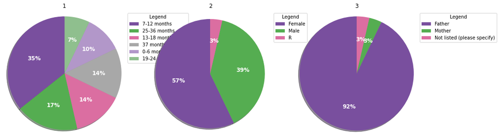

```python
childDemo = allIncoming[["How old is the 1st child?","What is the 1st child's gender?","What is your relationship to the 1st child?","How old is the 2nd child?","What is the 2nd child's gender?","What is your relationship to the 2nd child?"]]
childDemo.columns = [["1st child age","1st child's gender","resp relationship to 1st child","2nd child age","2nd child's gender","resp relationship to 2nd child"]]
childDemo1 = childDemo.iloc[1:, :3].dropna()
plotPies(childDemo1, getLabels(childDemo1), False, False)
childDemo2 = childDemo.iloc[1:, 3:].dropna()
plotPies(childDemo2, getLabels(childDemo2), False, False)
```

## Attending WPC - How and Why

66% of respondants have not applied to another childcare program; they are represented in following questions.

```python
print("Have you applied to another childcare program?")
s = allIncoming.iloc[:, 30].dropna().describe() # --> functions prohibit plotting one graph
print(str(s[3]/s[0]*100)[:5],"% of respondants say \"", s[2],"\".")
```

```
Have you applied to another childcare program?
65.71 % of respondants say " No ".
```

```
Why?
KEYS:
1. It is too expensive
2. I feel my child is not old enough
3. There is a lack of quality childhood care
4. I use a nanny
5. I use a family member
```

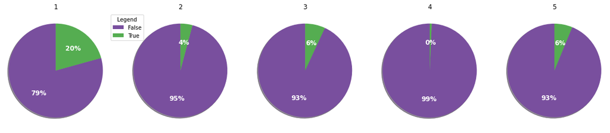

```python
print("Why?")
c = ["It is too expensive","I feel my child is not old enough","There is a lack of quality childhood care","I use a nanny","I use a family member"]
d = allIncoming.iloc[1:, 31:36]
d.columns = [c]
plotPies(d, ["False", "True"], True, True)
```

### Survey Questions

#### Why else have you not applied to day care?

```python
allIncoming.iloc[:,36].unique()[2:]
```

```
array(['While our oldest child is in daycare, it is too cost prohibitive to have our youngest two children in childcare.',
       'Prefer him to be at home ', 'He was childcare already ',
       'Stay at home mom',
       'I want to spend as much time with my child as possible and, honestly, at this time, we can afford to be a single income household.',
       'I am a stay at home mom', 'Limited part time options ',
       'Fear of entrusting my child’s well-being to a stranger(s)',
       'Not ready for him to go to daycare ',
       'Child stays at home with me', 'Work part time to stay at home',
       'I am not the parent, who prefers to "take care of child until he is vocal"',
       'Occasional Babysitter '], dtype=object)
```

##### Where else have you sought child care?

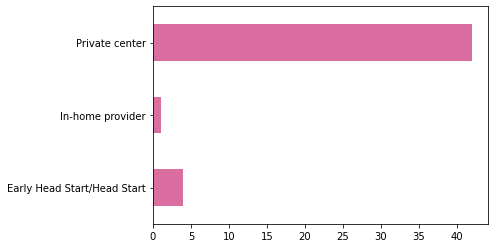

```python
plotSection("y", 37, 38, pie=False, plotBars="y", plotBarsHoriz=True)
```

### How respondants found the We PLAY center

```
KEYS:
1. Sign/Poster/flyer
2. Friend
3. Website
4. Social Media
5. Other org
```

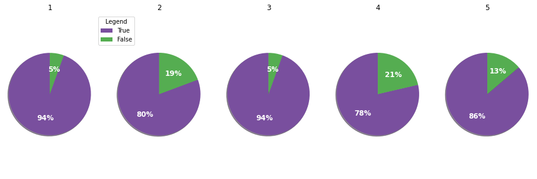

```python
cols = ["Sign/Poster/flyer", "Friend", "Website", "Social Media", "Other org"]
plotSection(cols, 120, 125, isNAct=True)
```

#### Answers differ greatly in the family survey

```
KEYS:
1. Sign/Poster/flyer
2. Friend
3. Website
4. Social Media
5. Other org
6. Laf-Fau Housing Office
7. Other
```

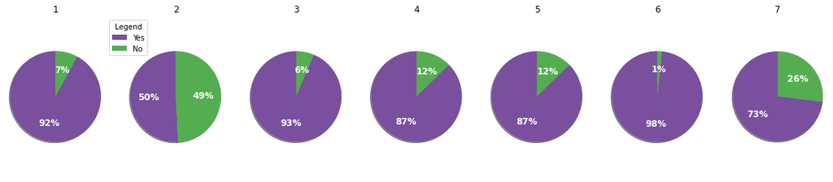

```python
how_found_WPC = familySurveyDf.iloc[1:, 10:17]
how_found_WPC.columns = ["Sign/Poster/flyer", "Friend", "Website", "Social Media", "Other org", "Laf-Fau Housing Office", "Other"]
plotPies(how_found_WPC, ["Yes", "No"], True, True)
```

```python
print("Other: ")
allIncoming.iloc[:,126].unique()[2:]
```

```
Other:
```

```
array(['We play staff ', 'Easter 2019 engagement ', 'Random',
       'Family (cousin) ', 'BabyCafe', 'Nolan baby cafe ',
       'A table at an event', 'Baby cafe ',
       'The early childhood development fair thing at Delgado',
       'Macaroni Kid newsletter ', 'Nola Baby Cafe', 'My doctor',
       'Midwife at touro', 'Ms. Melanie ', 'Macaroni Kid '], dtype=object)
```

*The family survey included sparse data on the ages/genders of a respondant's children, but we chose to omit it as it did not improve our model.*